# “Assesment of the detection distance of an autonomous recording unit in the cloud forest”

Amauri Sarmiento-Rojas, Miguel Equihua, Octavio Pérez-Maqueo, Brian Napoletano

enero 10, 2020

**ABSTRACT**

> Passive acoustic monitoring is an efficient and non-intrusive fundamental tool to provide information on the dynamics of spatial and temporal activity of the animals that produce sound. For designing research in the emerging field of Ecoacoustics, it is relevant to identify the detection space of recording devices. The evaluation of this range distance is a rather complex task, given that in the sound transmission there are multiple factors related to: acoustic attributes of the signal of interest, characteristics and configuration of the recording equipment, as well as some elements of the habitat and the environment (humidity, temperature, wind, precipitation, vegetation, topography, etc.). In the present project, using an experimental approach, we evaluated the range of scope of the omnidirectional microphone integrated in an automated recorder. Particularly, we identified the maximum distance at which the animals sounds, contrasting in frequency and call structure, are captured. Additionally, we analyzed the effect of distance, terrain slope, tree density and canopy cover on the loss of signals.

> *Keywords*: Acoustic monitoring, Detection space, Sound attenuation, Ecoacoustics.

# INTRODUCTION

Therefore, the evaluation of the recording range is a fairly complex task, since many factors are involved in the transmission of the sounds, from the acoustic nature of the signal of interest and the geophysical attributes of the site, to the characteristics and configuration of the recording equipment. This study has applications in the field of Ecoacoustics research, which studies the ecological relevance of the wildlife sounds.

In this project, we aimed to evaluate through an experimental approach, the detection range of the omnidirectional microphone integrated into the automatic recorder *SWIFT*. In particular, we identified the maximum distance at which all the sounds of animals of different frequencies are captured. We studied the transmission of each signal of interest according to its frequency category and its expected attenuation. We analyzed the effect of the distance, the terrain slope, the canopy cover and the density of arboreal vegetation on the loss of the signals. Since the intensity of the sounds decreases with distance and this attenuation is favoured in the presence of barriers such as vegetation, we expected a greater loss of amplitude occurring in closer distances and in sites with higher canopy coverage and tree density. On the other hand, given the inverse relationship between the distance and the frequency of the signal, we expect that the sounds with high dominant frequency will be attenuated in closer distances.

# METHODS

## *Study area*

The experiment was conducted in the Francisco Javier Clavijero Natural Protected Area, which presents secondary vegetation of cloud forest, located at southwest of the city of Xalapa, Veracruz. We chose six transects contrasting in tree density, physiographic form and terrain slope; one of these (transect 6) can approach a control site because of the flat terrain (less than 10° of inclination) and low tree density, located in the Clavijero Botanical Garden.

The fieldwork was carried out on May 8, 2018 from 11:00 a.m. to 5:00 p.m.; this schedule with the purpose of avoiding the peaks of activity of the local fauna that as background noise could cause masking of the signal of interest. During this period, the weather was with was abundant cloudiness, without precipitation, and no gusts of wind. The air temperature varied between 19.7 and 22.2 ° C, while the relative humidity changed between 92.3 and 99.9%; These variables were recorded with a portable meteorological microstation *Kestrell 4500*.

## *Characterization of site*

We estimated the tree density along each the transect, a circular plot of 5m radius was drawn at each test point and within this area (78.5 m<sup>2</sup>) we counted the number of trees with DAP> 10cm. We also shot photographs to estimate the percentage of canopy coverage using the *ImageJ* program. Finally, we calculated the average slope of the terrain (°) using a laser hypsometer *Nikon Forestry Pro*. This topographic variable was recorded pointing at a distance of 15m from the speaker point to the four cardinal points. This process was repeated in the six points of each transect (Figure).

[figure not shown]

Study area and experimental design indicating the location of the six transects, some representative photographs of the vegetation, as well as the physiographic forms according to each terrain profile.

## *Experimental design*

We carried an experiment to know the maximum recording distance (m), this consisted of reproducing a and re-recording a soundtrack containing prerecorded animals contrasting in their dominant frequency (that one with the highest energy). The detection space was considered as the reach distance from the signal source, in which its amplitude remains above a minimum detection threshold (Brenowitz 1982).

## *Animal sounds used for tests*

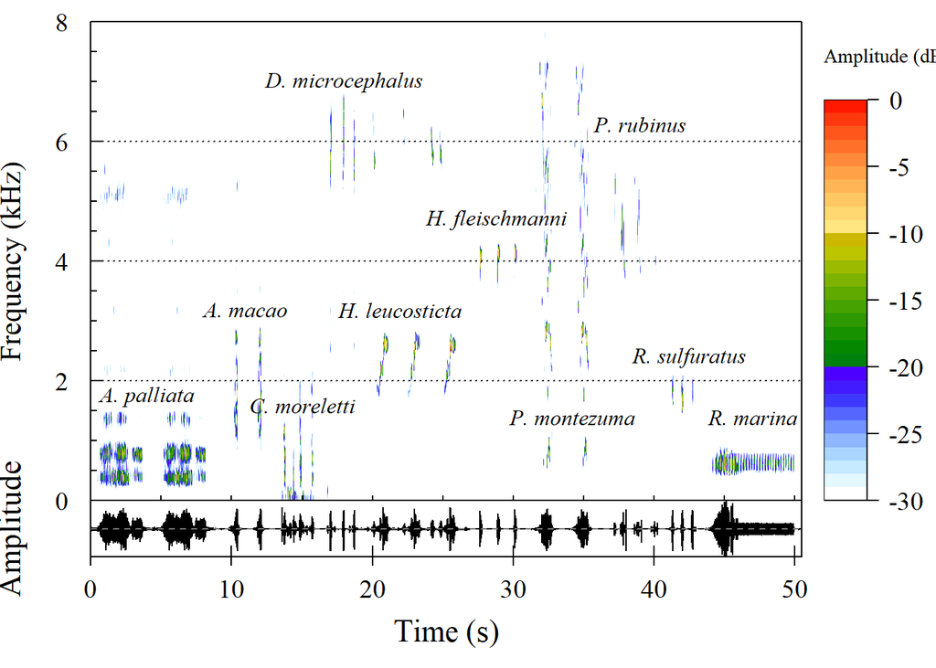

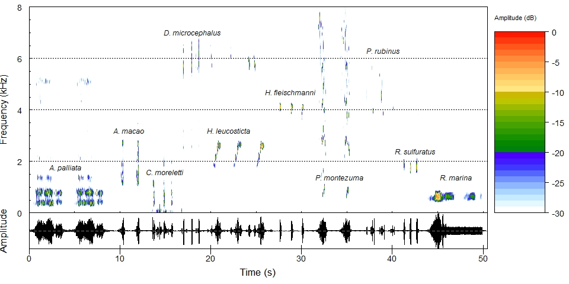

Spectrogram of the selected audios for the experiment, belonging to the ten species of vertebrate animals.

To standardize the intensity of the sounds, these were normalized to -4 dB using the free-use software *Audacity*. The recorder *SWIFT* was placed at a height of 2m above ground level. To play the audios we used a portable loudspeaker *XP8000RD Power&Co* that has a power of 4200 W. The volume was calibrated at an average intensity of 55 dB measured at 1m distance, as reference distance (*dref*), and at a height of 1m above the ground.

## *Assessment of the detection space*

In each recording obtained and for the ten signals of interest, the spectrum analysis tool *Plot Spectrum* was used in the *Audacity* program to measure the dominant frequency measured in number of cycles per second or Hertz (Hz), as well as its amplitude in decibels at full scale ([dBFS](https://en.wikipedia.org/wiki/DBFS)). Then, for each distance and for each signal of interest the amplitude values were averaged taking into account the logarithmic nature of this variable, using the formula: `10 ^ (obs_amplitude * -1) / 10`. These values were added and divided by the number of observations and again transformed into digital amplitude in dBFS. From the reference amplitude value, the acoustic extinction curves were constructed for each distance. The detection threshold occurs when a loss of the signal of interest is identified; that is, when it is no longer displayed on the spectrogram; in this case, we assigned a symbolic value of -100 dBFS.

## *Attenuation analysis by animal sound type*

To study the observed attenuation with respect to distance for each species, and according to its dominant frequency category; the expected attenuation curve was generated according to the theory of sound propagation. The following formula was used to calculate these values: $ SPL_expected = I_(ref)-20*log(d/dref) $; where the expected amplitude (*exp_amp*) is obtained with the reference amplitude (*iref*), the distance of interest (*d*) and the reference distance (*dref*). [Distance attenuation calculator] (https://www.omnicalculator.com/physics/distance-attenuation#inverse-square-law)

## *Effects of topography and vegetation*

To study the possible effect of topography and vegetation on signal reception, **for each species**, we made **linear models** of the measurements of **amplitude observed in full scale (dBFS)** in function of: the **expected amplitude (dbFS)**, the **recording distance (m)**, the **average slope of the site (°)**, the **density of tree stems with DAP> 10cm** and the **tree cover percentage**). We used the “glmulti” function to find the most appropriate model based on the corrected Akaike Information Criteria (AICc).

# RESULTS

## *Detection space of tested recorder*

We present the acoustic extinction curves generated for each site (Figure) and for each species (Figure) based on their average amplitude values, in decibels at full scale (dBFS), recorded for each distance.

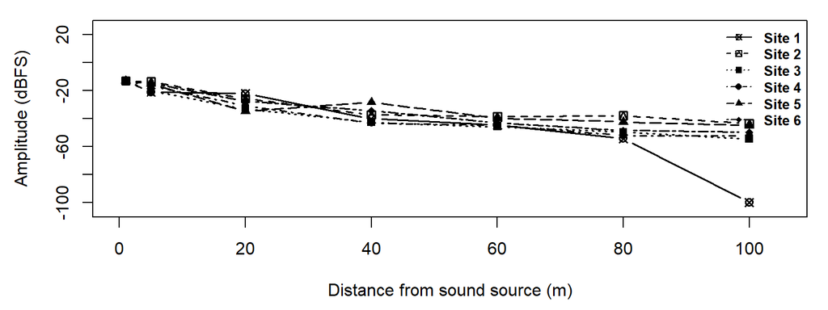

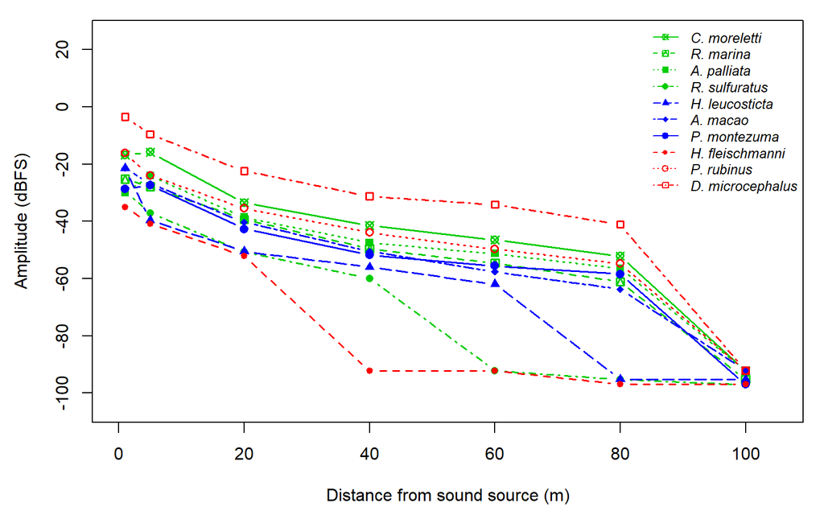

[figure not shown]

Attenuation curves with amplitude evaluated at six distances for six sites.

## *Atenuattion by animal sound type*

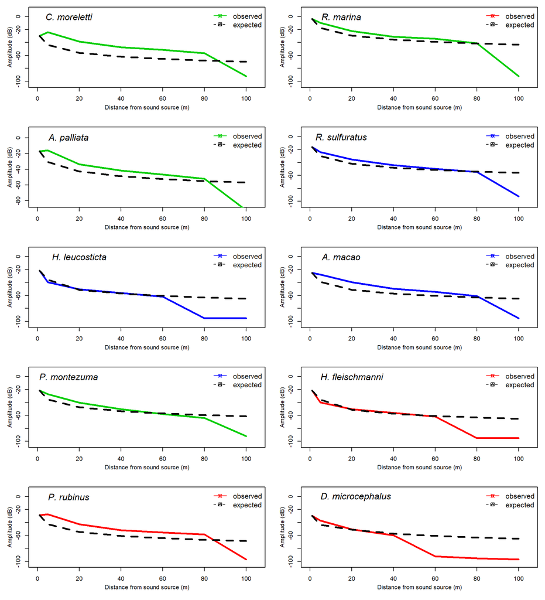

## *Effects of topography and vegetation*

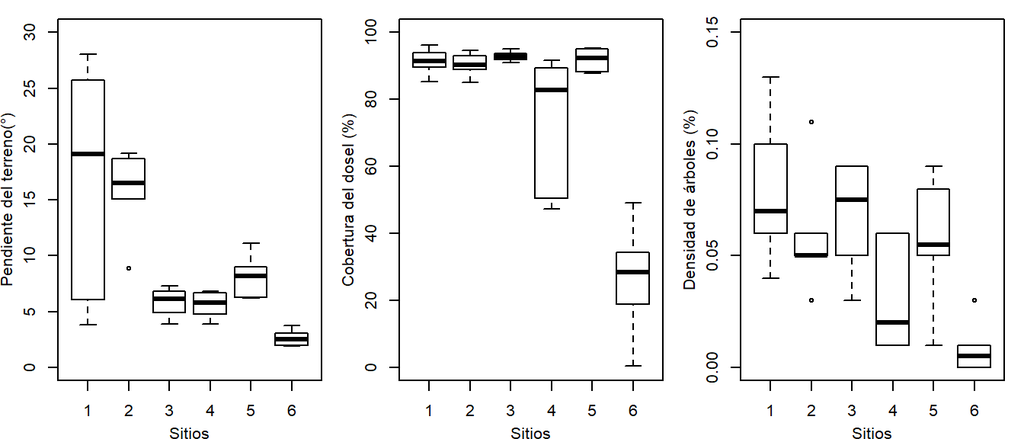

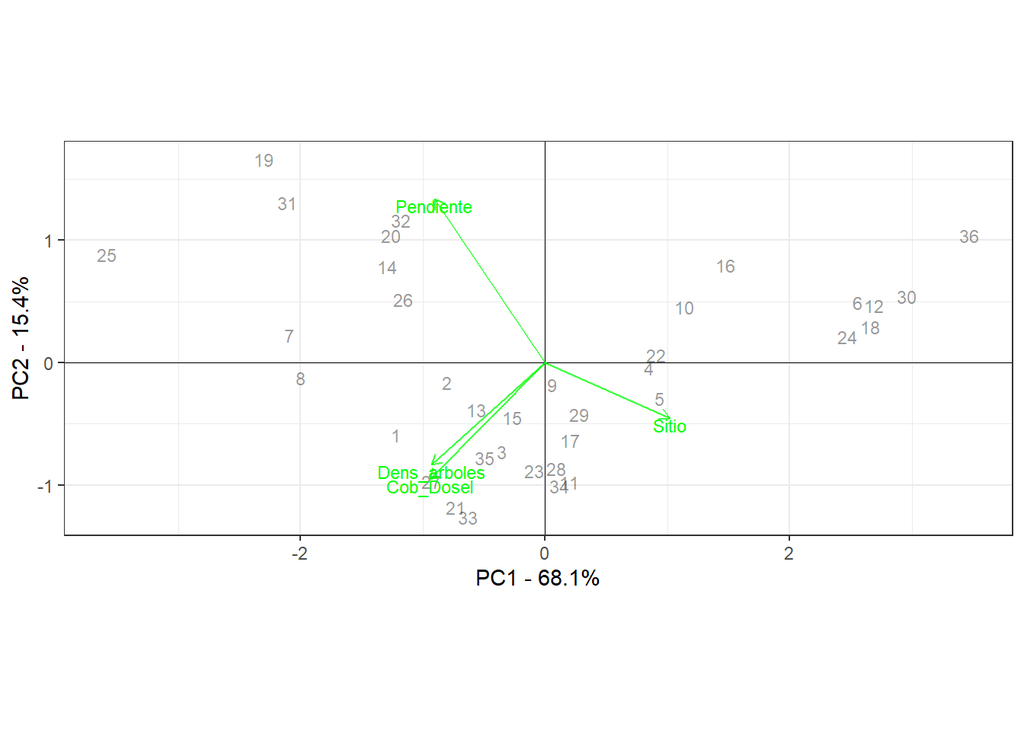

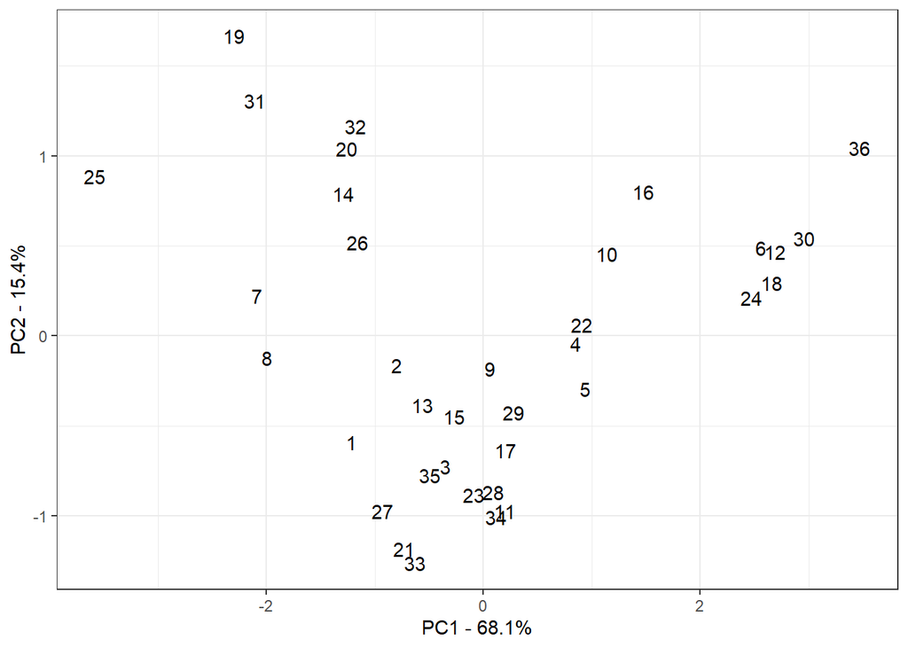

**Linear Model**

## *Model selection and fitting: theoretical vs empirical model*

The main signal is catched by the *offset* term; the intercept, which contains the *offset*, is clearly different from zero. In order to know the *offtset* effects, we plotted the intercept with its confidence intervals at 95%.

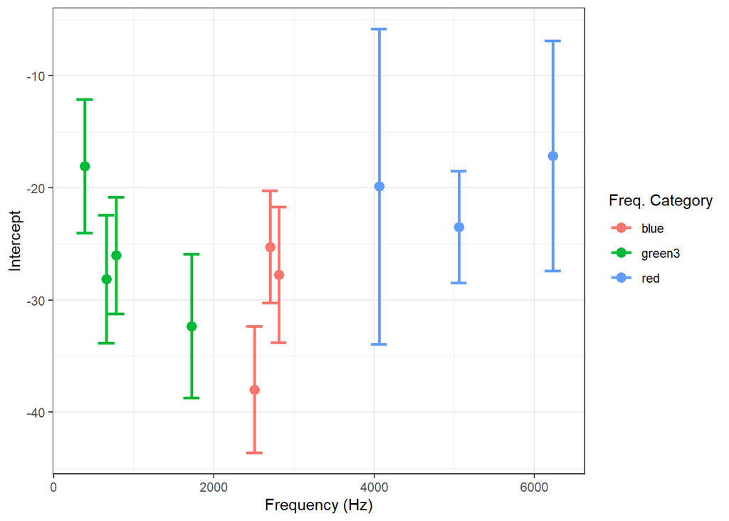

It is clear that, there is a certain common arrangement for the attenuation of all calls, and the onlyone that separates the most is that one with dominant frequency of 2500 Hz, which is attenuated apparently more than everyone.

In all cases, we found a small effect of distance with the same sign as the offset, so we could actually add it to the previous estimate. Then, there are the secondary effects of tree density, terrain slope and canopy coverage, which in variable form also have small effects compared to the size of the *offset*.

### *Model contrast approach*

We can also explore the convenience of adding some of the site characterization variables or an additional distance effect. The principal effects of these variables plus the term of *theoretical attenuation*. Using the *stepwise* strategy but without incorporating any interaction in order to make slight improvements that may more clearly have the contextual effect of the site’s characteristics on the sound behavior.

The issue of “identifiability of the call” is pending, in the sense how much distortion occurs to degrade the characteristics that allow differentiating the animals studied.

### *Do all calls fade in the same way: does the same model apply to all?*

We adjusted a model including theoretical attenuation in interaction with the species and of course, the main effects of both. For convenience the type of contrast used in R is *treatment*, which means that one of the conditions is chosen as a reference and all others are then expressed as the difference from that reference. Usually, the first treatment is taken as a reference, but anyone that interests may be chosen.

Almost all species could be modeled similarly, except for the sound of species 5 *(Henicorhina leucosticta)*.

This simplified model seems to account for the data almost as well as the original “complete model”, so, in spite of everything, in the case tested we could even simplify the model a little more, since several species seem not to differ either when initial condition: Sp1 == Sp3 == Sp7 == Sp10. When making this change, explanatory capacity of around 0.5% is lost.

# DISCUSSION

The maximum average distance at which most of the animal sounds of different frequencies are detected is 80 m, some sounds are attenuated and lost at 40m. As we expected, the high-frequency signals resulted in greater loss as the distance increases, these signals contain less pressure or less energy and tend to more easily degrade with obstacles.

The evaluated site variables of terrain slope and vegetation had no significant effect *per se* on attenuation. It would be interesting to study the effect of other topographic variables such as the terrain roughness, the orientation and the physiographic form of the site.

The main purpose of this project was to estimate the detection distance of the recorder which is especially relevant for studies in which it is intended to record the sound remotely and autonomously. On the contrary, it was not the objective of this project to evaluate the transmission of sounds, which could require another type of experimental design.

In the wildlife, animals emit vocalizations at different heights and some of them moves or change orientation while there are calling.

*Puntos a considerar:*

The detection space may vary according to weather conditions such as temperature, humidity, wind and precipitation, in the field is not possible to control this environmental variables.

There is no reference control signal (pure tone of 1kHz at 94 dB SPL which is the pressure of 1 Pascal), based on this normalization would be performed.

Review the frequency response of the horn, you may amplify certain frequencies further.

Consider the sensitivity of the microphone (frequency response and gain).

# ACKNOWLEDGEMENTS

To Esau Toaki Villareal Olvera for orientation on acoustic transmission issues. To Fernando González García (FGG) and Sofía Karen Pérez Cruz (SKPC) for contributing with some audio files used in this project.

# REFERENCES

Brenowitz, Eliot A. 1982. “The active space of red-winged blackbird song.” *Journal of Comparative Physiology A* 147 (4): 511–22. https://doi.org/10.1007/BF00612017.